# OB sniff-locked gamma — ridge & phase-continuity analysis (V2)

## threshTask — low

### Group mean TFR & peak-aligned TFR

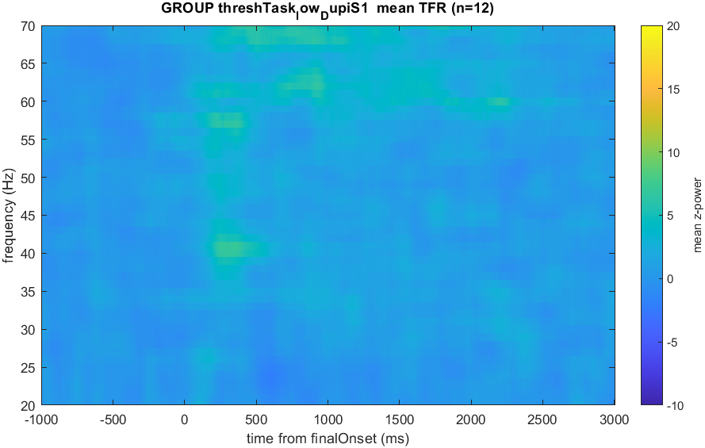

DupiS1 low mean TFR

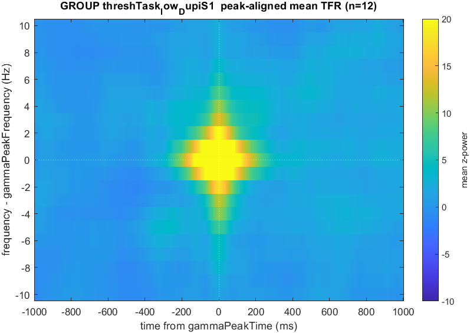

DupiS1 low peak-aligned

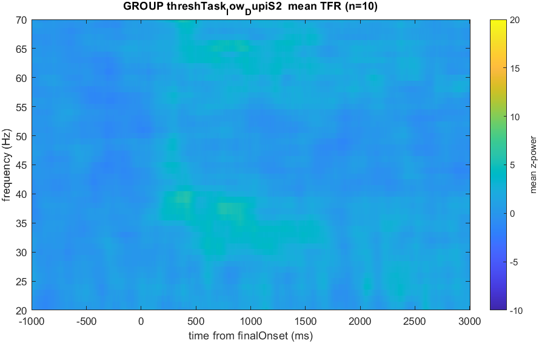

DupiS2 low mean TFR

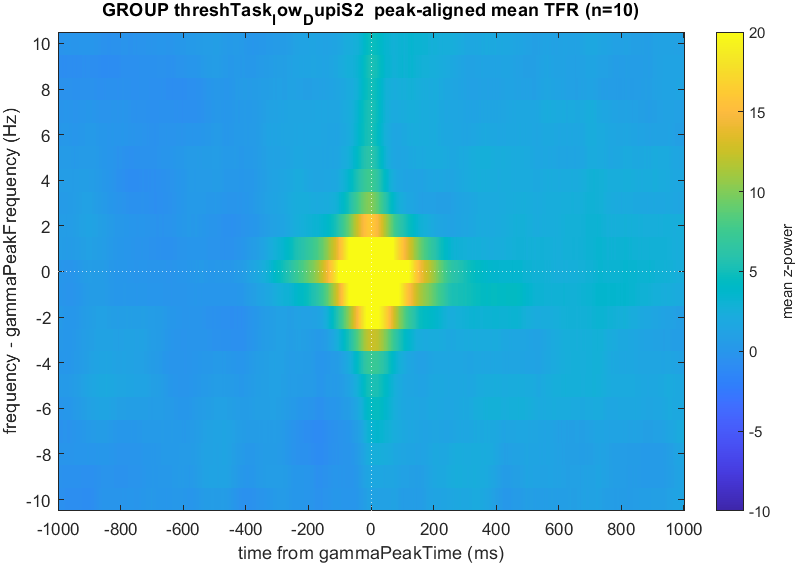

DupiS2 low peak-aligned

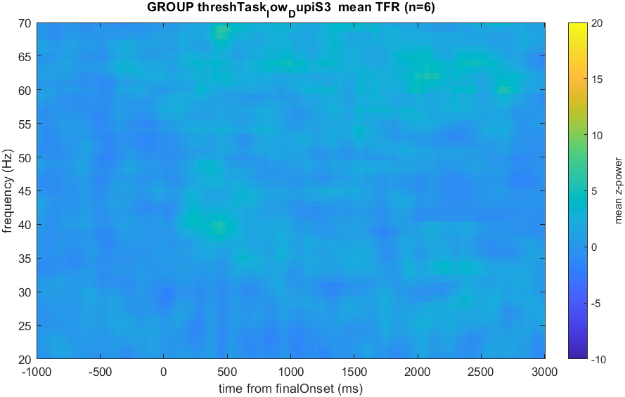

DupiS3 low mean TFR

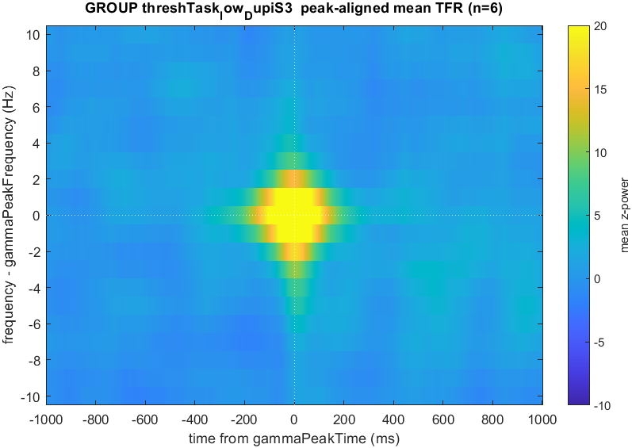

DupiS3 low peak-aligned

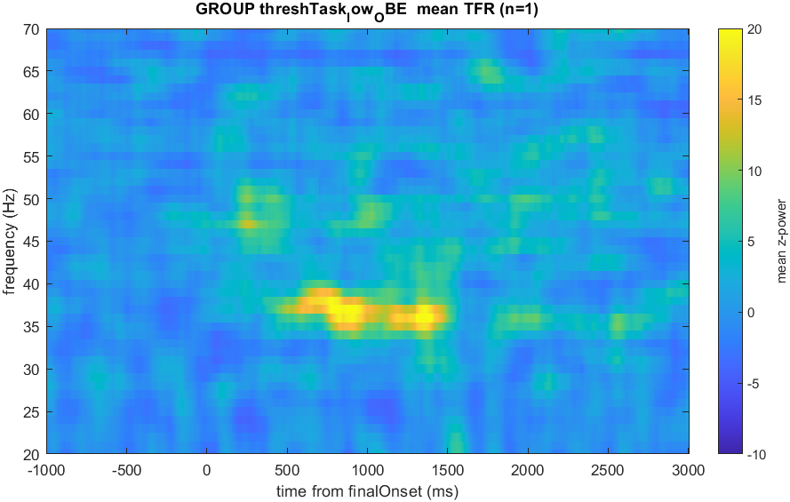

OBE low mean TFR

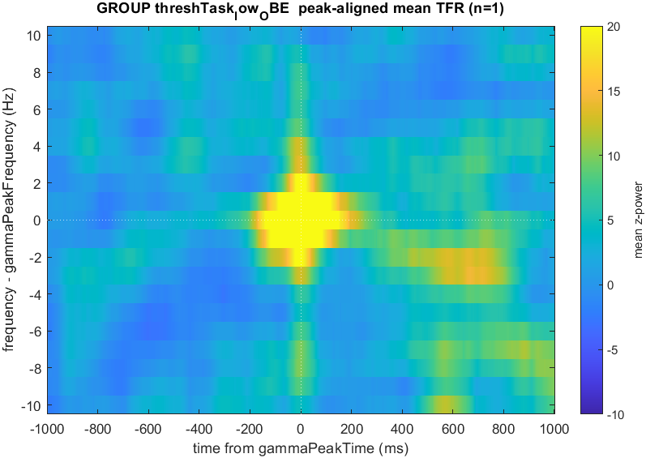

OBE low peak-aligned

### Single-trial examples (TFR + primary/secondary ridge)

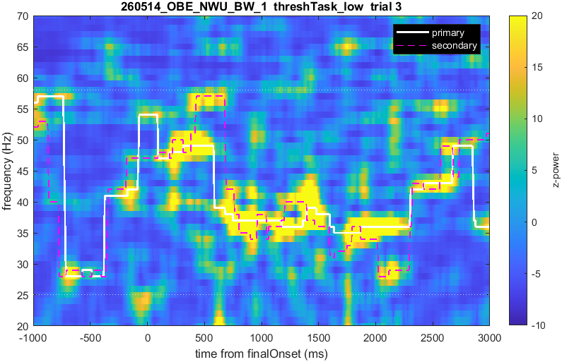

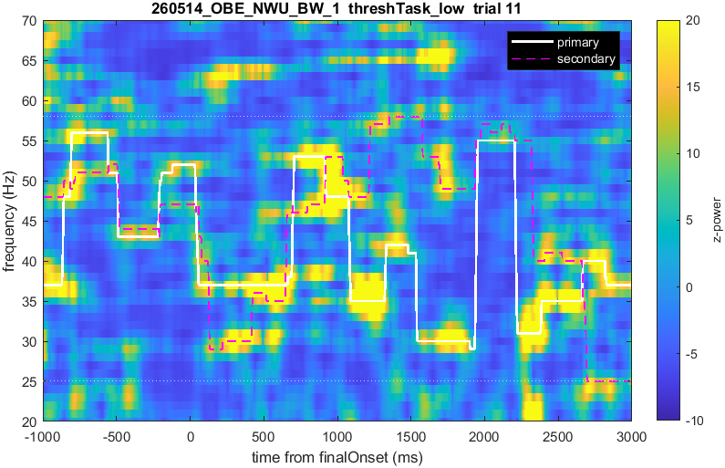

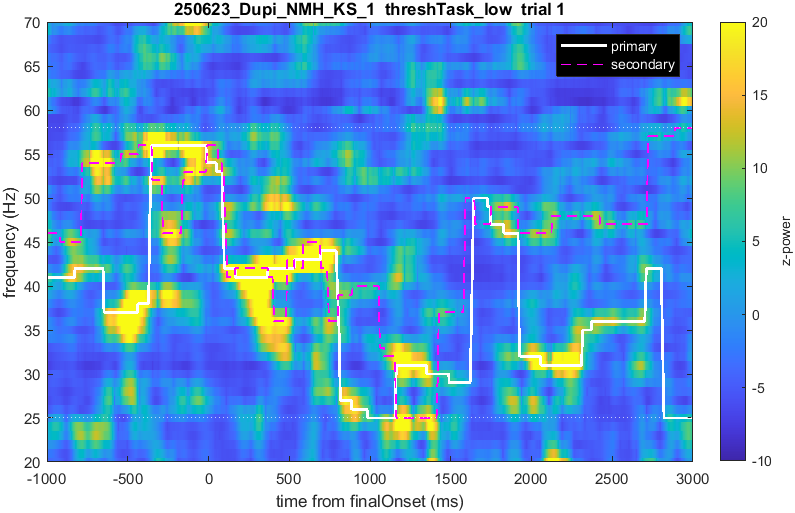

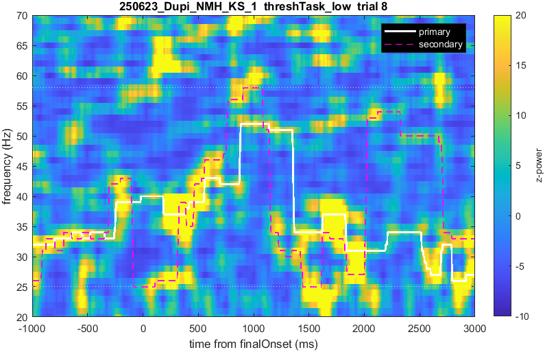

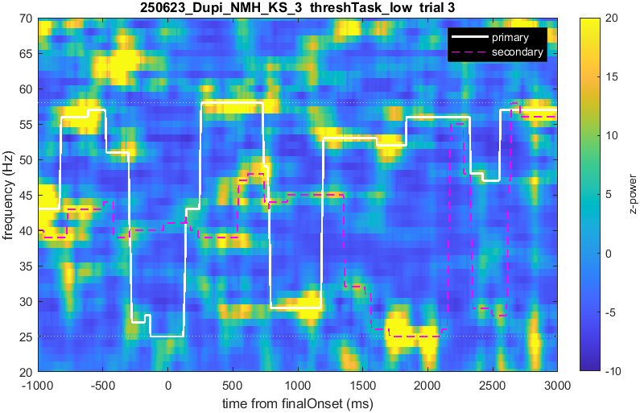

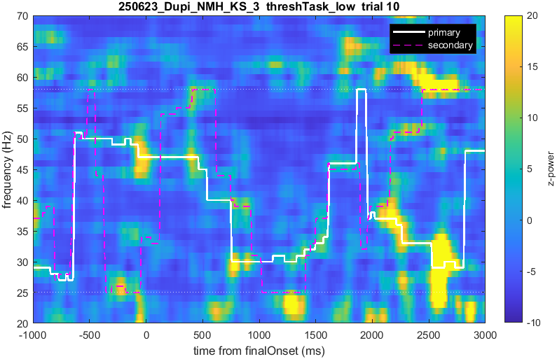

### Phase continuity (peak vs ridge)

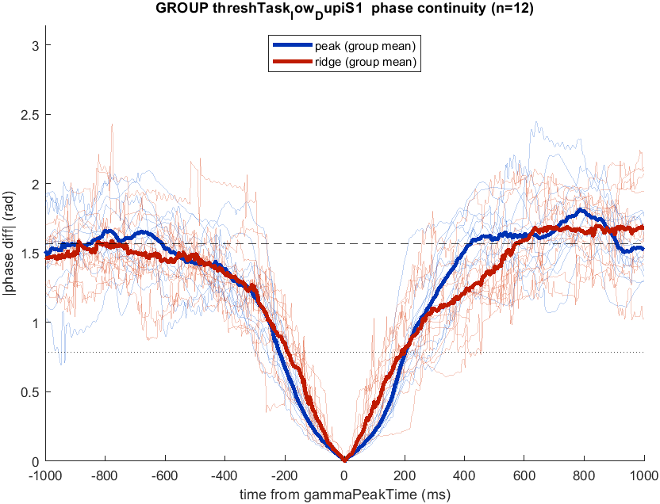

DupiS1 group

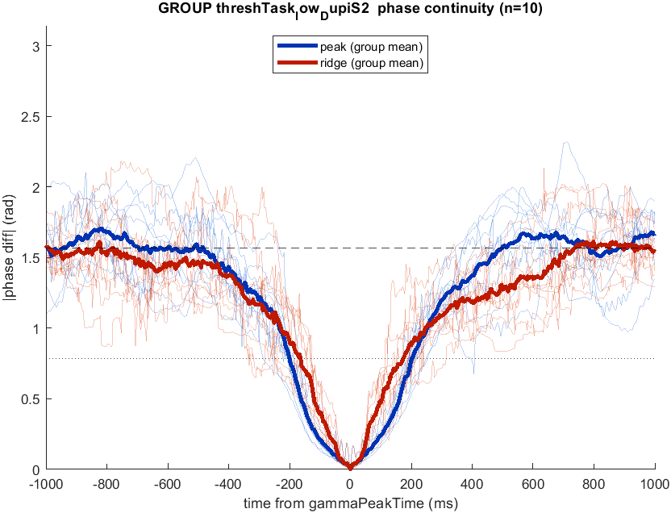

DupiS2 group

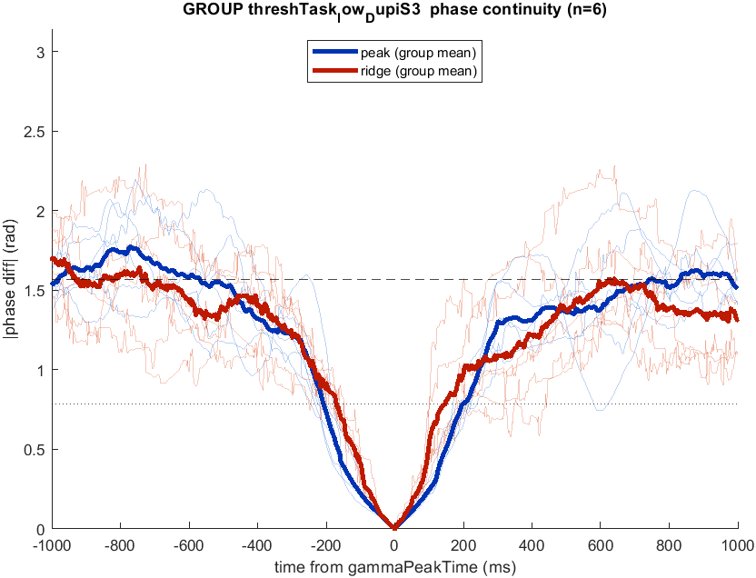

DupiS3 group

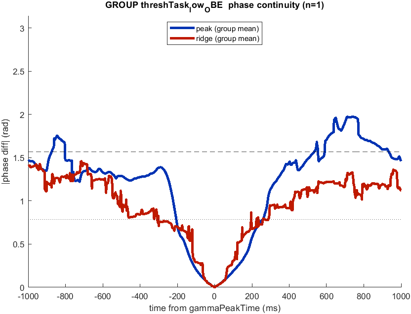

OBE group

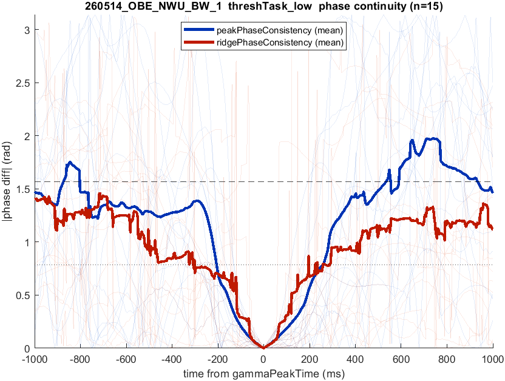

260514_OBE_NWU_BW_1

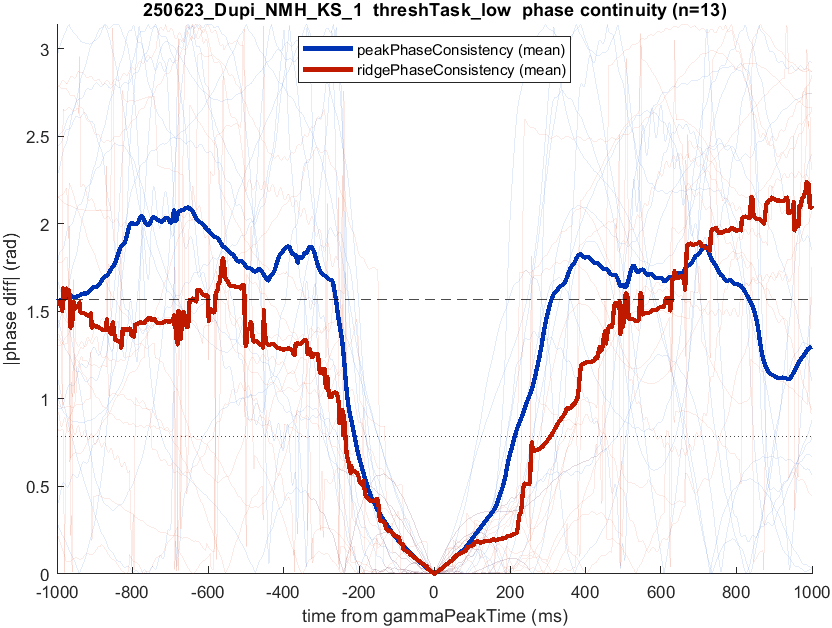

250623_Dupi_NMH_KS_1

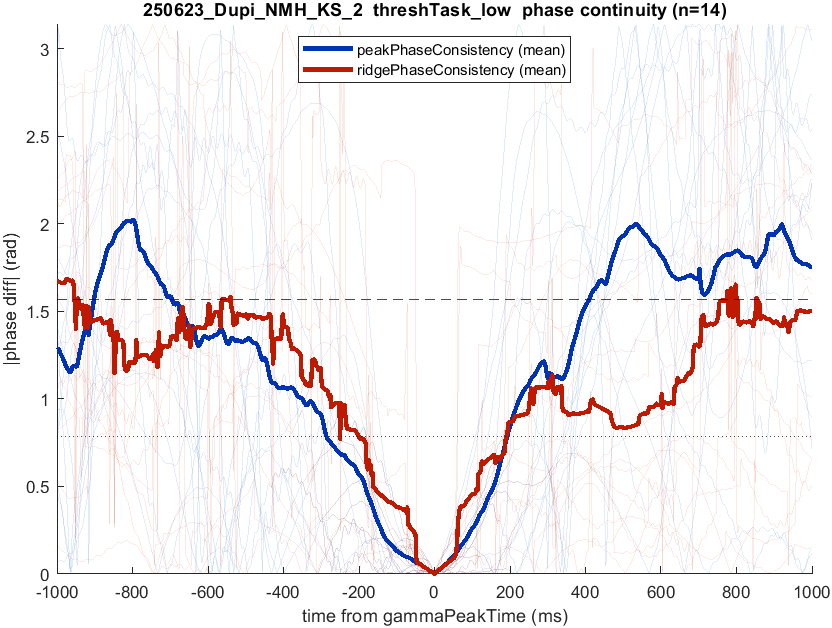

250623_DUPI_NMH_KS_2

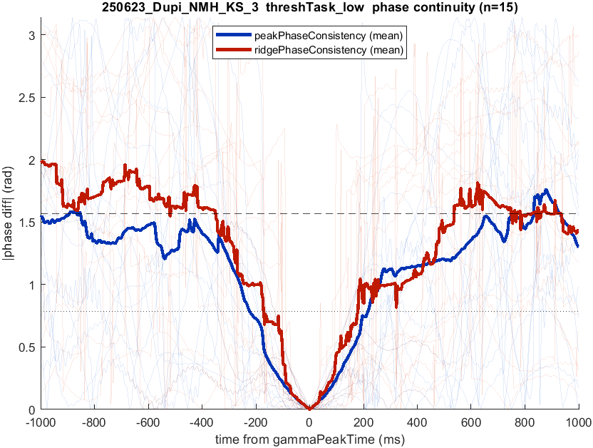

250623_Dupi_NMH_KS_3

- **DupiS1** (n=12 subj): no timepoints survive correction.
- **DupiS2** (n=10 subj): peak vs ridge |phase diff| differ (max-stat perm, corrected p<0.05) at 23 timepoints, -162 to 112 ms.
- **DupiS3** (n=6 subj): no timepoints survive correction.
- **OBE** (n=1): too few subjects for stats.

### Burst length (peak vs ridge)

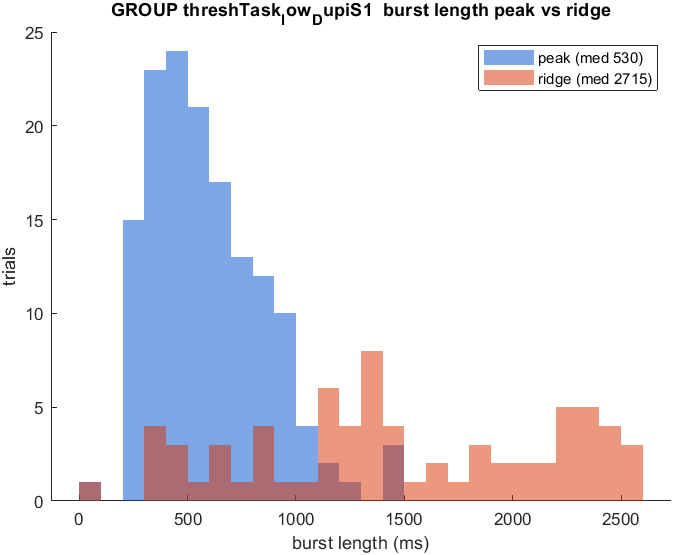

DupiS1 group

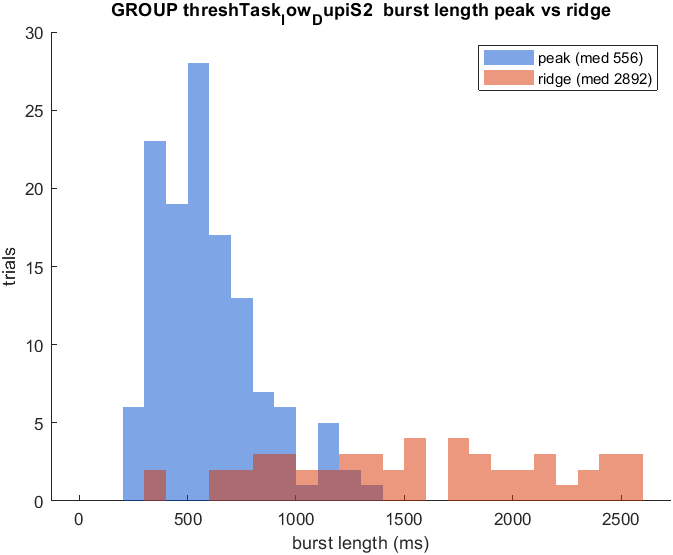

DupiS2 group

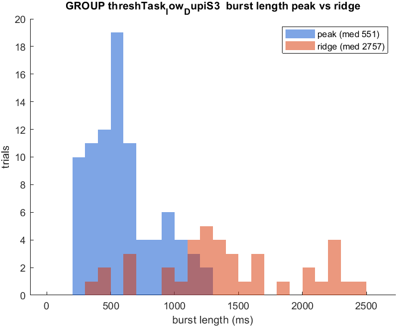

DupiS3 group

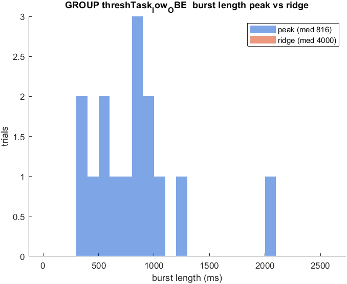

OBE group

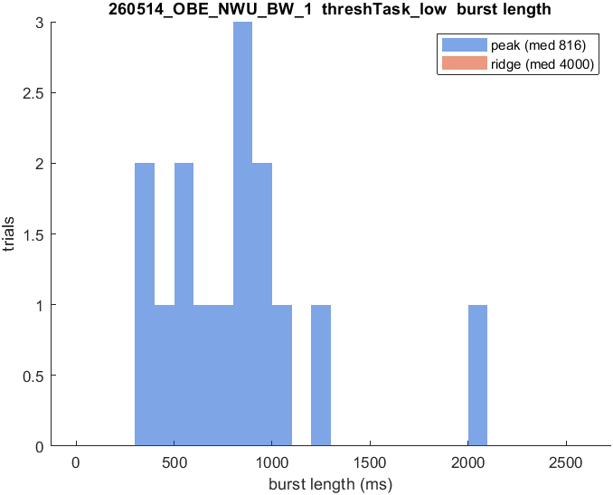

260514_OBE_NWU_BW_1

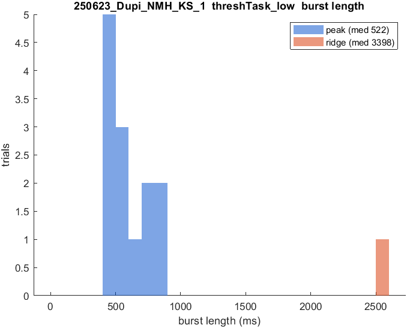

250623_Dupi_NMH_KS_1

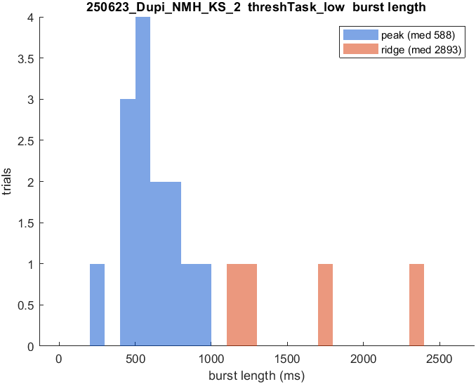

250623_DUPI_NMH_KS_2

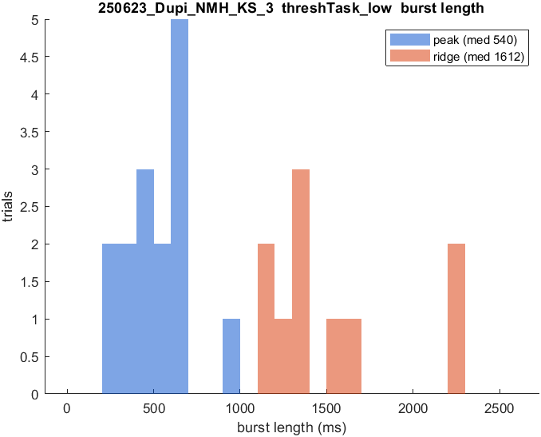

250623_Dupi_NMH_KS_3

- **DupiS1** (n=12): median peak 552 ms vs ridge 2612 ms; paired Wilcoxon p=0.0004883 (ridge−peak median diff 2040 ms).
- **DupiS2** (n=10): median peak 564 ms vs ridge 2804 ms; paired Wilcoxon p=0.001953 (ridge−peak median diff 2182 ms).
- **DupiS3** (n=6): median peak 558 ms vs ridge 2717 ms; paired Wilcoxon p=0.03125 (ridge−peak median diff 2078 ms).
- **OBE**: too few subjects.